# Data Cleaning Draft

Ellen Tedeschi

October 21, 2017

## Getting your Data into R

### Entering data directly

In some cases, you may want to enter data directly into R. This is easy with a small number of cases.

```r
# Direct Data Entry

score <- c(20, 16, 35, 19)

name <- c("Monica", "Michelle", "Paul", "Ellen")

year <- c(1, 1, 4, 3)

dataframe <- data.frame(name, score, year)
```

### Reading data into R

It’s also easy to introduce errors this way, and with a lot of data it would get tedious. Most of the time, you’ll be reading data from an external file, or opening up an existing dataset in R. Once you find the location of your files, what you do next will depend on the file format.

```r
# What's your working directory and where is the file you want?

#getwd()

list.files()
```

```
## [1] "DataCleaning_files"  "DataCleaning.Rmd"    "README_Study2.txt"
## [4] "Study1.csv"          "Study1.rda"          "Study2_Subjects.csv"
## [7] "Study2_Trials.csv"
```

```r
#setwd(#Set you working directory)

# What kind of file do you have?

## For .txt, .csv and tab-deliminated files

?read.table

# Try this one, and then look at the data
mydata <- read.table("Study1.csv")

# Add arguments to help R figure out how your data is organized
mydata <- read.table("Study1.csv", header=TRUE, sep=",", stringsAsFactors=FALSE)


# Other options include:
# read.csv, just like read.table but with better defaults for .csv
# read.delim, for when you have a separator that's not standard

## For getting data that's already in R-format

load("Study1.rda")

## For getting data from another program:
#install.packages("foreign")
#library(foreign)

#read.spss("<Path to file>")
#read.dta("<Path to file>")
# remember, all these may take more arguments to get your data exactly the way you want
# Use the help functions to get more details
```

## Inspecting your data

Now you have data, time to get some results! But wait! Are you sure this data is ok? Doing some basic steps to inspect your data now can save you lots of headaches later, and R makes it really easy.

Start by checking that you have the expected number of rows and columns in your data frame. You can do this by looking at the Environment window, or by asking R.

```r
# Number of rows and number of columns
nrow(mydata)
```

```
## [1] 50
```

```r
ncol(mydata)
```

```
## [1] 9
```

```r
# Names of columns
names(mydata)
```

```
## [1] "ID"          "Age"         "Sex"         "Condition"   "Personality"
## [6] "T1"          "T2"          "T3"          "T4"
```

```r
# look at the first few rows
head(mydata, 10)
```

```
##    ID Age    Sex Condition Personality T1 T2 T3 T4
## 1   1  21 Female         0          67  5  2  3  1
## 2   2  22 Female         1          63  4  1  5  2
## 3   3  24   Male         1          58  6  2  6  2
## 4   4  22 Female         1          51  2  3  6  5
## 5   5  19 Female         0          49  7  6  5  2
## 6   6  25 Female         1          45  6  3  6  5
## 7   7  24 Female         1          68  7  1  4  6
## 8   8  19   Male         1          58  4  7  3  4
## 9   9  21   Male         1          56  3  4  7  2
## 10 10  20 Female         0          74  6  1  6  2
```

### Rename a variable

Ok, looks good. But what is that fifth variable? What does that even mean? Luckily, this is your study and you know that it’s a personality questionnaire measuring neuroticism. Let’s fix that.

```r
names(mydata)[names(mydata) == 'Personality'] <- 'Neuroticism'
names(mydata)
```

```
## [1] "ID"          "Age"         "Sex"         "Condition"   "Neuroticism"
## [6] "T1"          "T2"          "T3"          "T4"
```

### Check for missing data

On problem you may have is missing data. Sometimes this is something you already know about, but you should check your data frame anyway to make sure nothing got missed in a data entry error.

```r
is.na(mydata)
```

```
##          ID   Age   Sex Condition Neuroticism    T1    T2    T3    T4
##  [1,] FALSE FALSE FALSE     FALSE       FALSE FALSE FALSE FALSE FALSE
##  [2,] FALSE FALSE FALSE     FALSE       FALSE FALSE FALSE FALSE FALSE
##  [3,] FALSE FALSE FALSE     FALSE       FALSE FALSE FALSE FALSE FALSE
##  [4,] FALSE FALSE FALSE     FALSE       FALSE FALSE FALSE FALSE FALSE
##  [5,] FALSE FALSE FALSE     FALSE       FALSE FALSE FALSE FALSE FALSE
##  [6,] FALSE FALSE FALSE     FALSE       FALSE FALSE FALSE FALSE FALSE
##  [7,] FALSE FALSE FALSE     FALSE       FALSE FALSE FALSE FALSE FALSE
##  [8,] FALSE FALSE FALSE     FALSE       FALSE FALSE FALSE FALSE FALSE
##  [9,] FALSE FALSE FALSE     FALSE       FALSE FALSE FALSE FALSE FALSE
## [10,] FALSE FALSE FALSE     FALSE       FALSE FALSE FALSE FALSE FALSE
## [11,] FALSE FALSE FALSE     FALSE       FALSE FALSE FALSE FALSE FALSE
## [12,] FALSE FALSE FALSE     FALSE       FALSE FALSE FALSE FALSE FALSE
## [13,] FALSE FALSE FALSE     FALSE       FALSE FALSE FALSE FALSE FALSE
## [14,] FALSE FALSE FALSE     FALSE       FALSE FALSE FALSE FALSE FALSE
```

[output cut: 36 more lines]

```r
# that's a lot to go through, just tell me if there are any
sum(is.na(mydata))
```

```
## [1] 1
```

```r
# that's better, now I know there's 1 missing value
```

In this case, the missing value is the Age value in row 39. You know you have this info somewhere on a paper form, so you go dig it up and want to replace it.

```r
mydata$Age[mydata$ID==39] <- 30
```

### Check for correct values

To look at some of the other variables, let’s use the table function. This works well for factors or variables with only a few different values. Our condition and sex variables are good here.

```r
table(mydata$Condition)
```

```
##
##  0  1
## 22 28
```

```r
table(mydata$Sex)
```

```
##
## Female  Femle   Male
##     21      3     26
```

When we look at the table for the Sex variable, we see another data entry problem. We have a third category that should really be another case of “Female”.We can fix all of these at once, but sometimes messing with factors is more complicated than numeric variables.

```r
mydata$Sex[mydata$Sex=="Femle"] <- "Female"

table(mydata$Sex)
```

```
##
## Female   Male
##     24     26
```

Now let’s look at the continuous variables. You can also look at these with the table function, but sometimes it’s easier to visualize. The histogram function is good here.

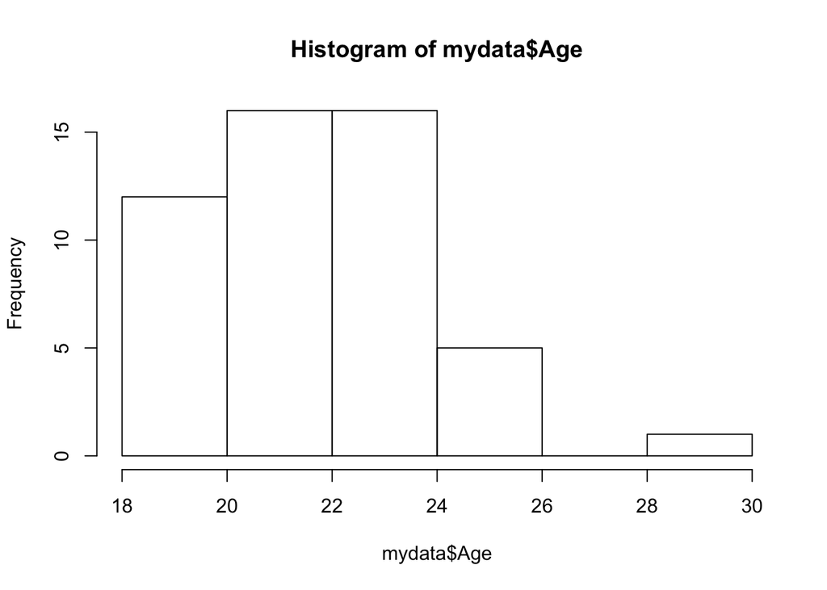

```r
hist(mydata$Age)
```

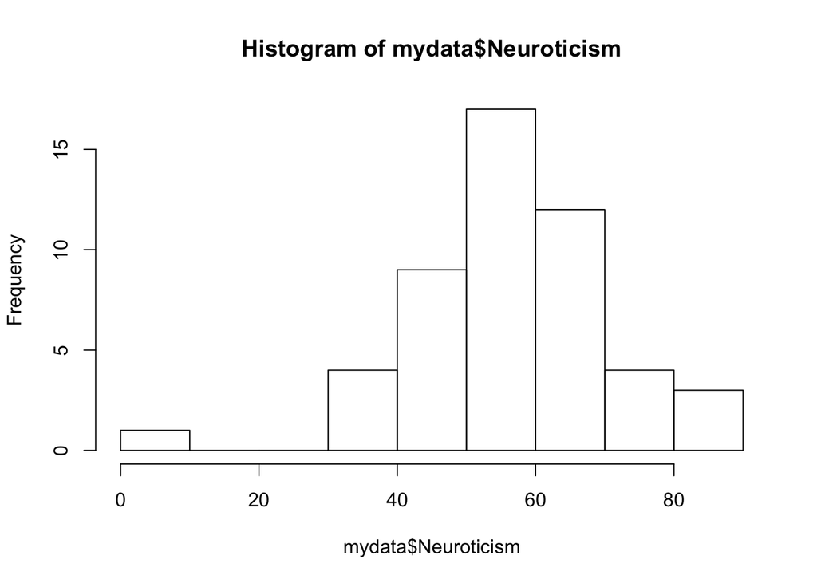

```r
hist(mydata$Neuroticism)
```

Looks like we have a potential outlier on the neuroticism score. This could be an entry error, but it could also be a real value that just happens to be really low. This is why data inspection is so important for later analysis - now you know that value is there, it’s up to you to decide how to deal with it.

## Getting ready for analysis

Now that we’ve gone through and cleaned up the problems, you can think ahead to how you’ll want to use this data.

### Recoding variables

Sometimes we want to treat categorical variables as factors, but sometimes we want to pretend they’re numeric (as in a regression, when binary variables can be coded as 0 and 1). Right now, Condition is coded as a binary numeric variable, but that’s not very informative, so you’d rather have the values be descriptive. Here, the function mapvalues from the plyr package is really useful. We’ll create a second variable instead of overwriting Condition

```r
library(plyr)
# Transform into factor with labels
mydata$ConditionF <- mapvalues(mydata$Condition, from = c("0", "1"), to = c("Control", "Treatment"))
```

### Calculating new variables

You may also want to recalculate or rescale some variables. For example, we can turn Neuroticism into a Z score, or calculate an average response across the four time points. For Z scores, you can use the scale() function. You can also use this to just mean-center the data.

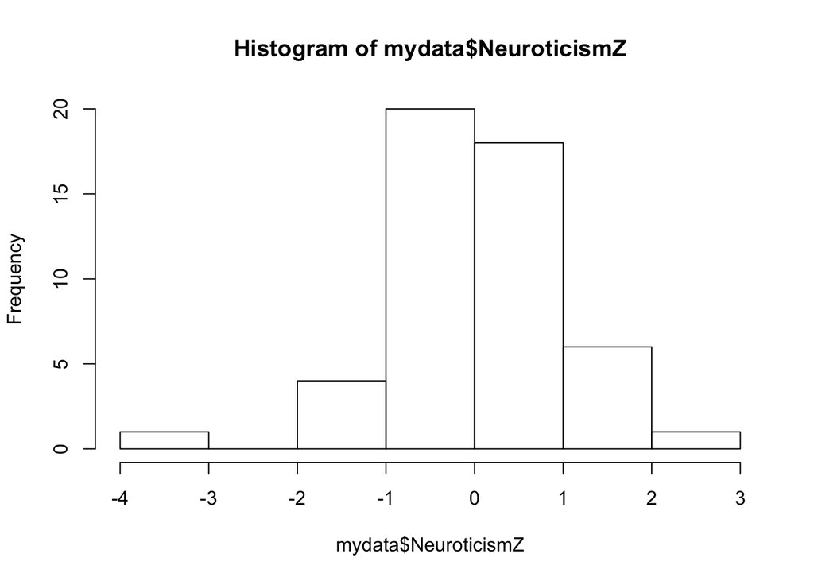

```r
# calculate Z scores
mydata$NeuroticismZ <- scale(mydata$Neuroticism, center = TRUE, scale = TRUE)
hist(mydata$NeuroticismZ)
```

```r
# one way to average multiple columns
mydata$Average <- rowMeans(mydata[c("T1", "T2", "T3", "T4")])
```

### Shaping data

Finally, you may want to change the layout of your data. Right now, our data frame is in “wide” format, which means that each row is a subject, and each observation gets its own column. For some analyses, you’ll need to use “long” format, where each row is an observation, and columns specify things like time and ID to differentiate the observations. There are lots of packages that can handle data reshaping, but I’ll show the gather and spread functions from tidyr

```r
library(tidyr)
# Key is the name for the new column that will identify which observation it is, and value is the name for the new column that will have the actual values in it. You can name these whatever you want.
mydata_Long <- gather(mydata, key="Time", value="Score", T1:T4)

# Spread lets you go back the other direction. This should be identical to the original mydata
mydata_Wide <- spread(mydata_Long, key="Time", value="Score")
```

## Saving your work

Once you’ve created a data cleaning script like this one, you’ll have a record of all the edits you’ve made on the raw data, and you can recreate your cleaned data just by running the script again. However, it’s often easier to save your cleaned data as its own file **(never overwrite the raw data)**, so when you come back to do analysis you don’t have to bother with all the cleaning steps.

You can always save data frames as a .csv for easy sharing and viewing outside of R.

```r
write.csv(mydata, file="Study1_Clean.csv")
```

However, you can also save in an R format that lets you save multiple variables/objects in the same file. For example, you might want to have a long and wide format, or one dataframe with all the data and one with just subject information. Saving as a .rda file allows you to save multiple objects at once for easy loading into R. You can also have the outputs of statistical models saved in these, along with their data.

```r
# Add as many objects as you want, separated by commas
save(mydata_Long, mydata_Wide, file="Study1_clean.rda")
```

## Your turn!

```r
# Read the data into R. The file is called "Study2_Subjects.csv". Check out the separate "README_Study2.txt" file for information on the study and variables.


# View the first 5 rows of the data frame


# Examine the data for issues. Some things to look for: are the column names logical? Are there missing values? Do the variable types make sense? (ie does everything that's a factor make sense as a factor, and does everything that's numeric make sense as numeric?) Are there values that don't make sense? Fix any issues you find.


# This study has three conditions, based on how long the subject kept their hand in cold water. Right now this is categorical, but you may want to look at it continuously. Make a new condition variable that's numeric.


# Each subject in this study filled out three related questionnaires, but these scores can be combined into a composite score but taking the sum. Create a new variable for this score.


# You see there's another .csv file for Study 2, this one's called Study2_Trials.csv. Open it and take a look. This frame has the same 10 subjects, but now it has reaction time data from a task with 30 trials. Create a new data frame that combines this with your subject level information. Hint: ?merge, by="ID"


# Now that you have a one frame with all the data, put it into long format. Each subject should have one row for each trial.


# You want to do a separate analysis only on the people who had a high score on the anxiety questionnaire. Create a new data frame with just the individuals who got 50 or higher. (Hint, check out ?subset for help)



# You should have 4 data frames now (subject level, trial level, combined, and the subset). Save them as a new .rda file for future use
```